# Writing your honors thesis

(Part 1)  
Federica Zoe Ricci  
UCI Statistics, PhD Student

2024-05-01

## What are we doing today and Friday?

- Addressing your doubts and concerns about thesis writing
- Discuss common mistakes
- Look at examples for what’s good or less-good
- Share tips

## Something about me

- I like Statistics - maybe I am weird
- I like writing - I am definitely weird :)
- I work with CS professor Erik Sudderth on statistical models for network data

fzricci@uci.edu

https://federicazoe.github.io/

## Something about you

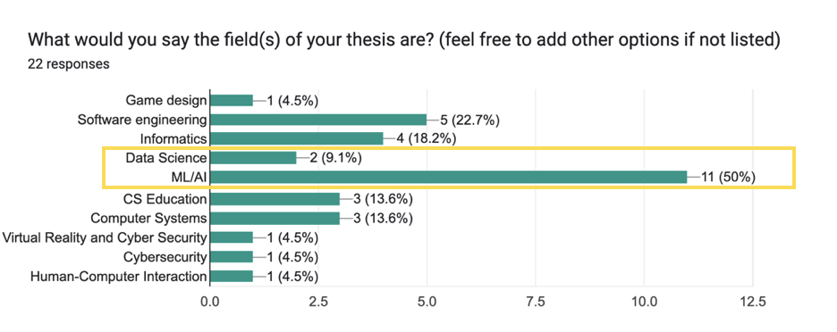

## Your deadlines and your progress

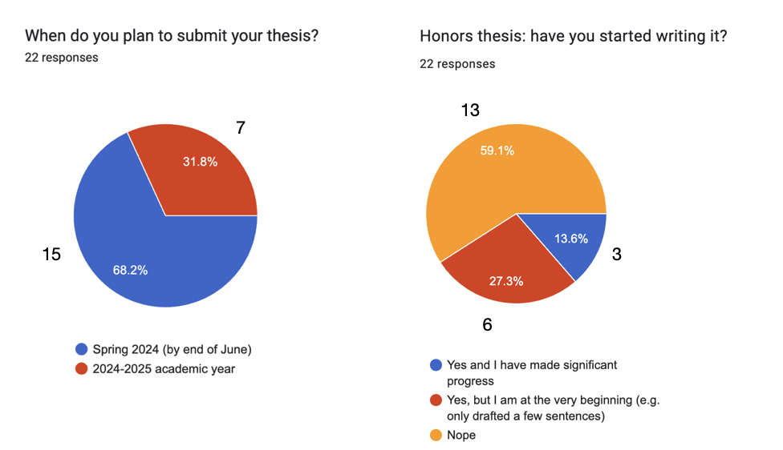

## The thesis you are planning to write

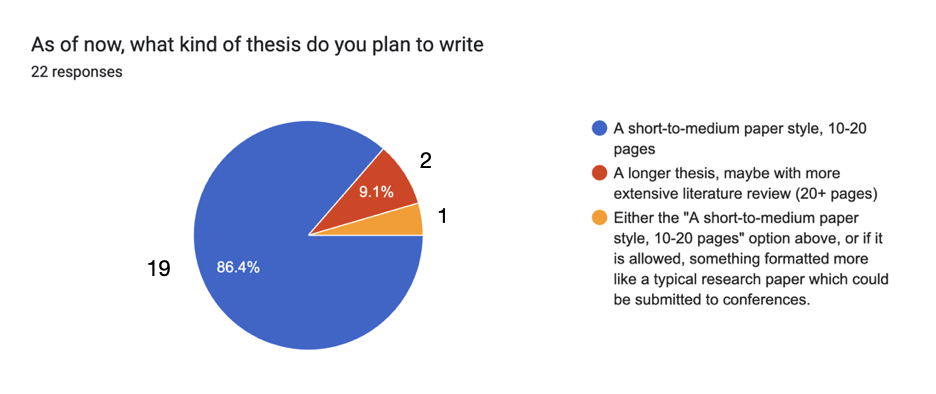

## Your confidence

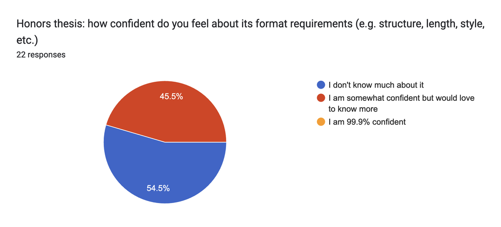

## Recurring doubts: Sections

[Quotes from survey responses indicating need to know more about what sections are included in a honors thesis.]

(Exact quotes are hidden in public version of workshop for protection of students’ data.)

## Sections of a short thesis / paper

- Abstract - *overview of the project*
- Introduction - *what is your project about?*
- Background - *what has been done before/what is known?*
- Methods - *what did you do and how?*
- Results - *what did you find out?*
- Discussion - *what do your findings mean?*

We will dig into each of these more!

## Recurring doubts: Standard Format?

[Quotes from survey responses indicating need to know more about what format/template a honors thesis should follow.]

(Exact quotes are hidden in public version of workshop for protection of students’ data.)

## A flexible thesis

*It is up to the student and their faculty advisor to determine the most appropriate form for their thesis, including questions such as exact format, page count, word count, headings, etc.*

(From [UCI honors research and thesis requirements](https://honors.uci.edu/campuswide-honors-research-and-thesis-requirements/))

## Examples of thesis (and formats)

[output not shown]

## Choosing *your* format

- Take a look at the examples and see which styles you like!
- If you choose a conference paper, there usually are templates, e.g. [NeurIPS](https://neurips.cc/Conferences/2023/PaperInformation/StyleFiles) (search for others!)
- UCI has [Word and LateX templates](https://guides.lib.uci.edu/gradmanual/templates) for a Master’s or PhD thesis, which you can use too
- Ask your advisor if they are on board with your choice

## Your challenges with writing

**Clarity**

What makes for a clear thesis or paper?

Clarity is **global clarity** + **local** **clarity** (e.g. individual sentences, figures etc.)

## What affects overall clarity?

- what content is included/not included

  Examples of common problems?
  - Not explicit about what you worked on exactly
  - Not explaining why you chose the method you used

    [A good example](https://drive.google.com/drive/folders/1LLAew3n71PpblH7A0lZZcYQNlAH93xum) (highlighted text in Sec 1.2, Sec. 2 and Sec. 3)
  - Good principle: *every element in a story must be necessary, and irrelevant elements should be removed*

## What affects overall clarity?

- how content is organized in your thesis
  - your focus should be clear very soon

    [Define a metric, then use it - example](https://drive.google.com/drive/folders/1gRAAnH8o6nkAfnyC3VDZxffvuHXireWx)

    (highlighted text in Sec. 4.1 and 4.4)
  - can you tell what the story is?

## Ok but.. how do *I* write a clear thesis

- Generally good idea to work a great deal on the outline, until you see that it does tell a story
  - Sometimes advisors can help you with this, sometimes it is hard..
  - Run the outline by a peer (ideally someone who is also writing a thesis)

  **Volunteer needed**

  Two people who have *made significant progress* on your thesis, come share with us your story!

## What affects local clarity?

- Individual-sentence clarity

  Common problems:
  - Using terminology or acronyms that you have not defined

    When I was wrong: It does *not* read as ‘advanced’

    Better to use less terminology, but well defined

    [Define a metric well - example](https://drive.google.com/drive/folders/1gRAAnH8o6nkAfnyC3VDZxffvuHXireWx)

    (highlighted text in Sec. 4.1)
- Clarity of Figures and Tables

  Common problems:
  - Throwing results at the reader without making sure they can be understood
  - Not referencing and not making use of your Tables and Figures in the text

    [These tables have been abandoned - example](https://drive.google.com/drive/folders/1cn6axcKdCeDPqJ2g-U3hsUU-Ht58SaiX) (Figure 1, 2)

## What we covered today

- There is a structure to the thesis, but it’s pretty flexible
- Each of you knows at least one example thesis close to their thesis topic - see Examples of thesis (and formats)
- What makes for a clear thesis, overall
- What makes for clear individual sentences, figures and tables

## What we are doing Friday

- What exactly makes for good abstract, introduction, background, methods, results and discussion sections
- Tackle another one of the challenges you mentioned: how to get started

# The End (of Part 1)